# R Notebook

### Next we’ll perform some feature engineering - merging and/or modifying variables where it seems appropriate.

**Outlet Type Combinations?** First we’ll take a look at the ‘Outlet_Type’ variable, in particular, whether Supermarket Type2 and Supermarket Type3 ought to be combined into one category.

```r
#Print out the mean sales grouped by Outlet_Type
data %>%
        group_by(Outlet_Type) %>%
        summarise(mean_sales = mean(Item_Outlet_Sales, na.rm = TRUE))
```

| Outlet_Type | mean_sales |
| --- | --- |
| Grocery Store | 339.8285 |
| Supermarket Type1 | 2316.1811 |
| Supermarket Type2 | 1995.4987 |
| Supermarket Type3 | 3694.0386 |

The mean sales prove to be significantly different for Supermarket Type2 and Type3 (in fact there’s not a bad spread overall), so we won’t merge these categories. Merging two categories which could potentially be impacting our output variable could confound our analysis.

**Item Visibility** Second, we’ll get back to the issue of ‘Item_Visibility’, which had the mysterious minimun of zero.  
The zero values are most likely just missing information, so we’ll impute Item_Visibility based on the given item’s (Item_Identifier’s) mean visibility.

```r
#Group by the item ID and replace zero values in Item_Visibility with the corresponding item's average visibility across all stores
data <- data %>%
        group_by(Item_Identifier) %>%
        mutate(Item_Visibility = replace(Item_Visibility, Item_Visibility == 0, mean(Item_Visibility)))
summary(data$Item_Visibility)
```

```
    Min.  1st Qu.   Median     Mean  3rd Qu.     Max.
0.003575 0.031150 0.057190 0.069710 0.096930 0.328400
```

Now we have absolute visibility stats for all products in all stores, but in order to determine how a particular product’s visibility at a given location impacts its sales at that location, we need to know how the product’s visibility at that particular location compares with the product’s visibility at other locations.  
To understand this, we’ll need to create a new metric, namely, the ratio of the product’s visibility at a given store to its mean visibility across all stores.

```r
#Calculate the new variable, 'Item_Visibility_MeanRatio'
data <- data %>%
        group_by(Item_Identifier) %>%
        mutate(Item_Mean_Visibility = mean(Item_Visibility)) %>%
        mutate(Item_Visibility_MeanRatio = Item_Visibility / Item_Mean_Visibility) %>%
        select(-Item_Mean_Visibility)
```

**Item Type Recategorization** Here let’s take a look at mean sales by Item_Type to see if there’s any worthwhile rearranging we can do

```r
data %>%
        group_by(Item_Type) %>%
        summarise(mean_by_type = mean(Item_Outlet_Sales, na.rm=TRUE)) %>%
        arrange(desc(mean_by_type))
```

| Item_Type | mean_by_type |
| --- | --- |
| Starchy Foods | 2374.333 |
| Seafood | 2326.066 |
| Fruits and Vegetables | 2289.010 |
| Snack Foods | 2277.322 |
| Household | 2258.784 |
| Dairy | 2232.543 |
| Canned | 2225.195 |
| Breads | 2204.132 |
| Meat | 2158.978 |
| Hard Drinks | 2139.222 |

[output cut: 6 more lines]

I’m curious to see what the ‘Others’ category looks like

```r
data %>%
        filter(Item_Type == 'Others') %>%
        do(head(.))
```

| Item_Identifier | Item_Weight | Item_Fat_Content | Item_Visibility | Item_Type | Item_MRP | Outlet_Identifier | Outlet_Establishment_Year | Outlet_Size | Outlet_Location_Type | Outlet_Type | Item_Outlet_Sales | source | Item_Visibility_MeanRatio |
| --- | --- | --- | --- | --- | --- | --- | --- | --- | --- | --- | --- | --- | --- |
| NCI31 | 20.000 | Low Fat | 0.081658450 | Others | 35.0190 | OUT018 | 2009 | Medium | Tier 3 | Supermarket Type2 | 585.9040 | train | 0.8749848 |
| NCI31 | 20.000 | Low Fat | 0.081492092 | Others | 35.5190 | OUT045 | 2002 | Small | Tier 2 | Supermarket Type1 | 1025.3320 | train | 0.8732022 |
| NCI31 | 20.000 | low fat | 0.136124989 | Others | 38.3190 | OUT010 | 1998 | Small | Tier 3 | Grocery Store | 146.4760 | train | 1.4586034 |
| NCI31 | 20.000 | Low Fat | 0.081453600 | Others | 36.8190 | OUT049 | 1999 | Medium | Tier 1 | Supermarket Type1 | 768.9990 | train | 0.8727898 |
| NCI31 | 12.600 | Low Fat | 0.080933328 | Others | 37.5190 | OUT027 | 1985 | Medium | Tier 3 | Supermarket Type3 | 842.2370 | train | 0.8672150 |
| NCI31 | 20.000 | Low Fat | 0.081311780 | Others | 37.8190 | OUT035 | 2004 | Small | Tier 2 | Supermarket Type1 | 439.4280 | train | 0.8712701 |
| NCJ19 | 18.600 | LF | 0.118419683 | Others | 58.3588 | OUT045 | 2002 | Small | Tier 2 | Supermarket Type1 | 1545.9876 | train | 0.9409272 |
| NCJ19 | 18.600 | Low Fat | 0.118180011 | Others | 56.2588 | OUT046 | 1997 | Small | Tier 1 | Supermarket Type1 | 1030.6584 | train | 0.9390228 |
| NCJ19 | 18.600 | Low Fat | 0.197809110 | Others | 55.6588 | OUT010 | 1998 | Small | Tier 3 | Grocery Store | 114.5176 | train | 1.5717317 |
| NCJ19 | 12.600 | Low Fat | 0.117607719 | Others | 55.2588 | OUT027 | 1985 | Medium | Tier 3 | Supermarket Type3 | 2748.4224 | train | 0.9344756 |

[output cut: 170 more lines]

```r
data %>%
        filter(grepl('NC', Item_Identifier)) %>%
        group_by(Item_Type) %>%
        distinct(Item_Type)
```

| Item_Type |
| --- |
| Household |
| Health and Hygiene |
| Others |

```r
NA
```

Only these 3 Item_Types in unconsumables. It may make sense to combined Others with Health and Hygiene, but the Household type mean sales is considerably higher than the other two.  
As such maybe there’s a better way to group Item_Types than by ID code. (In addition to NC=‘non-consumables’, there is FD=‘foods’ and DR=‘drinks’, but it doesn’t immediately seem to make sense to combine item types in to these three categories).

In fact, let’s combine item types by utility/necessity, which seems to me like it may be more correlated with sales than whether the item happens to be food or not. Consumers will be looking to purchase some of all three ID categories (food, beverage, and non-consumable) in order to sustain their livelihood. Is there not some form of decreasing marginal returns to consumer surplus when filling your shopping cart with food vs. beverage vs. household goods, etc.? Won’t you get more benefit from the first unit of laundry detergent than the 400th potato?  
SO, that said let’s group the item types as best we can by their average sales and a judgement of necessity.

Looking at the mean_by_type column for the 16 item types above, let’s see if we can’t create groups based on the mean sales, and how likely the AVERAGE consumer may be to buy from a certain group.  
What first catches my eye is the top selling item types, from ‘Starchy Foods’ down to ‘Breads’. Once you get into the ‘Meat’ and ‘Hard Drinks’ categories, you may be cutting out a larger portion of consumers who won’t be purchasing these items, or at least not as regularly as, say, ‘Fruits and Vegetables’.  
From ‘Meats’ down to ‘Breakfast’ seems to make a nice 2nd category. After ‘Breakfast’, average sales drop by over 100, and we get categories that you’d maybe just purchase in smaller quantities when you run out of supplies(namely ‘Health and Hygiene’ and ‘Baking Goods’), or maybe on special occasions (for ‘Soft Drinks’).  
Note: The top two categories, ‘Starchy Foods’ and ‘Seafood’ also stand out to me, but ‘Starchy Foods’ just seems to me a really vague way to categorize (like, aren’t ‘breads’ starchy as well?), and we don’t have enough information with this dataset to know exactly what’s in there (though I imagine it would be pastas, rice, etc.). That said I’m hesitant to put it in one category alone with ‘Seafood’. Seafood tends to be expensive in the U.S., so it makes sense that mean sales would be relatively high, but ‘Starchy Foods’ is probably leading sales due to the quantity that customers by. These are completely different products with high sales for different reasons, so I won’t create a new category on the basis of sale numbers just for these two.

OK, so let’s go ahead and label these 3 groups in a new column

```r
#Add item types to variables representing our new categories
sales_high <- c('Starchy Foods', 'Seafood', 'Fruits and Vegetables', 'Snack Foods', 'Household', 'Dairy', 'Canned', 'Breads')
sales_med <- c('Meat', 'Hard Drinks', 'Frozen Foods', 'Breakfast')
#Create the categories 'High Sales', 'Medium Sales', and 'Low Sales' in new column, 'Item_Type_Aggregate'
data <- data %>%
        group_by() %>%
        mutate(Item_Type_Aggregate = ifelse(data$Item_Type %in% sales_high, 'High Sales', ifelse(data$Item_Type %in% sales_med, 'Medium Sales', 'Low Sales')))
data %>%
        group_by(Item_Type_Aggregate) %>%
        distinct(Item_Type_Aggregate)
```

| Item_Type_Aggregate |
| --- |
| High Sales |
| Low Sales |
| Medium Sales |

**Outlet Establishment Year** Next we come to a variable we can definitely improve on for our analysis: ‘Outlet_Establishment_Year’. We’re going to create a new variable, ‘Outlet_Years’, to more intuitively represent location age.

```r
#Subtract year established from 2013, as 2013 is the year in which this sales data was collected
data  <- data %>%
        mutate(Outlet_Years = 2013 - Outlet_Establishment_Year)
summary(data$Outlet_Years)
```

```
   Min. 1st Qu.  Median    Mean 3rd Qu.    Max.
   4.00    9.00   14.00   15.17   26.00   28.00
```

**Item Fat Content** Next we’ll deal with the mislabelling of the Item_Fat_Content categories

```r
#Just a reminder of what the existing category names are
data %>%
        group_by(Item_Fat_Content) %>%
        distinct(Item_Fat_Content)
```

| Item_Fat_Content |
| --- |
| Low Fat |
| Regular |
| low fat |
| LF |
| reg |

```r
#Replace redundant category names with 'Low Fat' and 'Regular' for the sake of consistency
data$Item_Fat_Content <- recode(data$Item_Fat_Content,
                                LF = 'Low Fat',
                                `low fat` = 'Low Fat',
                                reg = 'Regular')

#And we musn't forget to change the fat content label for non-consumable items
data <- data %>%
        mutate(Item_Fat_Content = replace(Item_Fat_Content, grepl('NC', Item_Identifier), 'Non-Consumable'))
#Check to make sure we have just the two categories remaining
data %>% group_by(Item_Fat_Content) %>% select(Item_Fat_Content) %>% apply(2, table)
```

```
               Item_Fat_Content
Low Fat                    6499
Non-Consumable             2686
Regular                    5019
```

### Before constructing a model with our tidied and modified data, let’s do some visualizaiton of the relationships between individual attributes and overall sales

**Sales on Item_MRP**

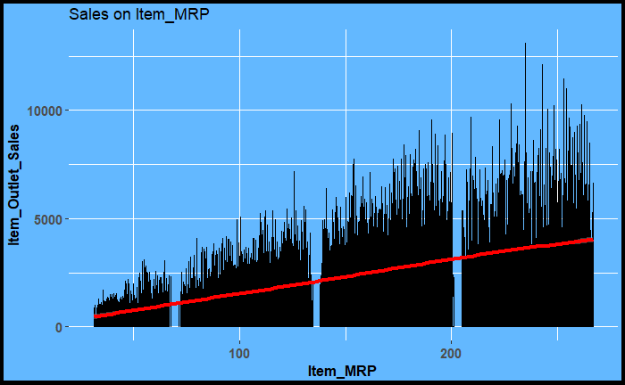

```r
#Simply Item_Outlet_Sales on Item_MRP
ggplot(data, aes(x = Item_MRP, y = Item_Outlet_Sales)) +
        geom_density(stat = 'identity') +
        geom_smooth(color = 'red', size = 1.5) +
        ggtitle('Sales on Item_MRP') +
        bigmart_theme
```

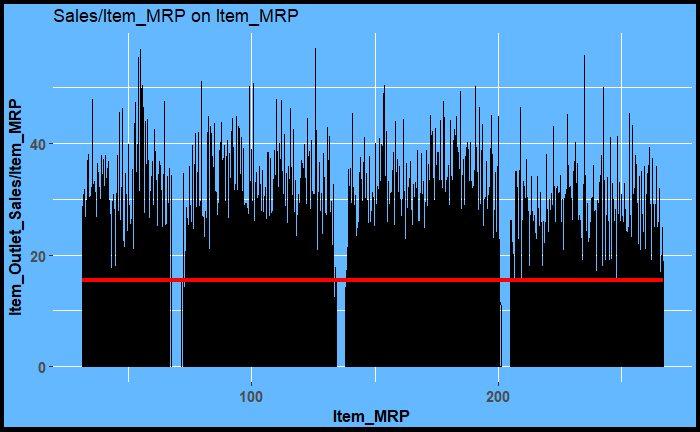

```r
#And dividing sales by the price to adjust for the fact that sales is basically price * quantity
ggplot(data, aes(x = Item_MRP, y = Item_Outlet_Sales / Item_MRP)) +
        geom_density(stat = 'identity') +
        geom_smooth(color = 'red', size = 1.5) +
        ggtitle('Sales/Item_MRP on Item_MRP') +
        bigmart_theme
```

As anticipated, the correlation between price and sales comes from the way in which Item_Outlet_Sales is calculated to begin with

**Preparing data for model development and testing** Prepare to split back into train and test sets

```r
#Drop columns we replaced
data <- data %>%
        select(-c(Item_Type, Outlet_Establishment_Year))
#Set item and outlet ID pairs to row names and coerce character columns into factors (by converting data to data.frame)
ID_cols <- paste(data$Item_Identifier, data$Outlet_Identifier)
data_df <- as.data.frame(unclass(data), row.names = ID_cols)
#Split back into train and test on 'source' column
train <- data_df %>%
        filter(source == 'train')
test <- data_df %>%
        filter(source == 'test')
#Drop unnecessary columns
train <- train %>%
        select(-source)
test <- test %>%
        select(-c(source, Item_Outlet_Sales))
```

Export prepared train/test sets to csv files

```r
write_csv(train, 'train_new.csv')
write_csv(test, 'test_new.csv')
```

```r
train_1 <- train %>%
        select(-c(Item_Identifier, Outlet_Identifier))
```

**Random Forest Model** Now it’s time to test out our model..

```r
library(randomForest)
rf <- randomForest(Item_Outlet_Sales ~ ., ntree = 100, data = train_1)
plot(rf)
print(rf)
```

[output not shown]

```r
varImpPlot(rf, sort = T, n.var = 10,
           main = 'Top 10 - Variable Importance')
```

[output not shown]

```r
#Variable Importance
var_imp = data.frame(importance(rf,
                                 type=2))
# make row names as columns
var_imp$Variables = row.names(var_imp)
var_imp <- var_imp[order(var_imp$IncNodePurity,decreasing = T),]

ggplot(var_imp, aes(x = Variables, y = IncNodePurity)) +
        geom_histogram(stat = 'identity', fill='blue') +
        theme(axis.text.x = element_text(angle = 45, hjust =  ))
```

[output not shown]

```r
#library(caret)
#library(rpart.plot)
#train_ctrl <- trainControl(method = "repeatedcv", number = 10, repeats = 3)
#dtree_fit <- train(Item_Outlet_Sales ~ ., data = train, method = "rpart",
#                   parms = list(split = "information"),
#                   trControl=train_ctrl,
#                   tuneLength = 10
#                   )
```

```r
#cols_to_drop <- c('Item_Weight', 'Item_MRP', 'Outlet_Establishment_Year')
#data <- data %>%
#        select(-one_of(cols_to_drop))

#item_vis_means <- data %>%
#        group_by(Item_Identifier) %>%
#        summarise(mean = mean(Item_Visibility))
#item_vis_means
```